# هوش مصنوعی

## پروژه پنجم(فاز دوم) - بررسی برخی از مسائل شبکه های عصبی به کمک Tensorflow

### دکتر فدایی - دکتر مرادی

### محیا قینی -810196615

###### دی 1399

## هدف پروژه

در فاز قبل این پروژه تنها با کمک کتابخانه numpy یک شبکه عصبی Feed Forward طراحی و پیاده سازی کردیم. با چالش ها و سختی های آن آشنا شدیم. در دنیای امروز با وجود کتابخانه های پیشرفته پایتون کمتر پیش می آید شبکه های عصبی از پایه پیاده سازی شوند. در طی این پروژه می خواهیم با کمک کتابخانه TensorFlow و رابط سطح بالای Keras پیاده سازی و مسائل شبکه های عصبی که از مهم ترین و پرکاربردترین ساختار های یادگیری ماشین است را بررسی کنیم.

## صورت مسئله

به ما مجموعه عکس های ریه افراد مختلف داده شده است. حال از ما خواسته شده است شبکه عصبی طراحی کنیم و با کمک داده های آموزشی که داریم به گونه ای شبکه را آموزش دهیم که مجموعه دیگری از داده ها(آزمون) را با دقت بالایی در گروه های نرمال، کووید 19 و ذات الریه دسته بندی کند. البته هدف اصلی بررسی مسائل و مواردی است که در معماری شبکه عصبی می توانیم در نظر گیریم و دقت شبکه را تحت تاثیر قرار دهد.

# Read data from drive & unzip it

## کار با داده ها

داده هایی که داریم حجم بالایی دارند. بنابراین برای اینکه سرعت کار با آن بالاتر رود، پروژه در google colab و با استفاده از GPU پیاده سازی شده است. البته این محیط چالش های خود را مانند قطع شدن اتصال و محدودیت در استفاده از GPU را داشت امّا بدون آن تنها فراخوانی داده ها مدت طولانی نیاز داشت. قطعه کد پایین بدین جهت پیاده سازی شده است که داده ها را بدون آنکه با صرف چندین روز زمان از حالت فشرده خارج سازیم، تنها در Google Drive قرار دهیم و با کمک Google colab به آن متصل شویم و داده فشرده را فراخوانی و در قسمت داده های colab ذخیره کنیم. سپس با دستور مناسب آن را از حالت فشرده خارج میکنیم و داده های آماده پیمایش و بررسی به دست می آوریم.

```python
from google.colab import drive
drive.mount('/content/drive')
```

```python
 !cp "/content/drive/MyDrive/xray.zip" .
```

```python
!unzip xray.zip
```

## کتابخانه های استفاده شده در حل مسئله

برای این مسئله از کتابخانه های زیر استفاده شده است:  
- کتابخانه tensorflow.keras:  
همانطور که بالاتر گفته شد از این کتابخانه به جهت پیاده سازی و بررسی تاثیر عوامل مختلف بر شبکه عصبی استفاده می کنیم.  
- کتابخانه matplotlib.pyplot :  
این کتابخانه برای ترسیم نمودار های دقت و loss داده های آزمون و آموزش در پروژه استفاده می شود.  
- کتابخانه numpy:  
این کتابخانه برای یافتن کلاس از one hot استفاده می شود.  
- کتابخانه sklearn.metrics:  
این کتابخانه برای گرفتن گزارش دقیقی از معیارهای گوناگون روی داده تمرین و تست در پروژه استفاده می شود.

```python
from tensorflow.keras import *
import matplotlib.pyplot as plt
import numpy as np
from sklearn.metrics import classification_report
```

# Question 1

در این قسمت تابعی جهت خواندن داده ها و تبدیل آنها به grayscale و اندازه 80*80 پیاده سازی شده است. در این قسمت تاکید شده است داده ها نرمال نشوند اما در بخش های بعد نیاز به نرمال سازی داریم. بنابراین هنگام فراخوانی بایستی کاربر مشخص کند تمایل به نرمال سازی داده دارد یا خیر. اگر دارد داده هنگام خواندن با rescale = 1/255 خوانده می شود و در غیر اینصورت اتفاقی برای داده نمی افتد. در نهایت با کمک متغیر های تعریف شده برای داده ها تعداد هر کدام از آموزش و آزمون و تعداد دسته ها و اینکه هر دسته بیانگر چیست نشان داده می شود.

```python
def analyzeData(path, normalize = False):
  dataGenerator = preprocessing.image.ImageDataGenerator(
      rescale = ((1.0/255.0) if normalize else None)
  )
  data = dataGenerator.flow_from_directory(
      path,
      target_size = (80,80),
      batch_size = 32,
      color_mode = "grayscale"
  )
  print("Size of data is: %d - Number of classes is : %d - Classes are : %s" % (data.n, data.num_classes, data.class_indices))
  return data
```

#### فراخوانی و چاپ اطلاعات مرتبط با داده های آموزش

```python
trainData = analyzeData("/content/Data/train", normalize=False)
```

```
Found 5144 images belonging to 3 classes.
Size of data is: 5144 - Number of classes is : 3 - Classes are : {'COVID19': 0, 'NORMAL': 1, 'PNEUMONIA': 2}
```

#### فراخوانی و چاپ اطلاعات مرتبط با داده های آزمون

```python
testData = analyzeData("/content/Data/test", normalize=False)
```

```
Found 1288 images belonging to 3 classes.
Size of data is: 1288 - Number of classes is : 3 - Classes are : {'COVID19': 0, 'NORMAL': 1, 'PNEUMONIA': 2}
```

# Question 2

## 2.1.Plot sample for each class

**2.1) از هر دسته موجود فقط یک تصویر و نام دسته نمایش دهید.**

در این قسمت برای راحتی کار چند تابع پیاده سازی شده است:  
1) getLabel: این تابع از داده onehot مرتبط با داده، کلاس آن را با یافتن ستونی که بیشترین مقدار دارد، می یابد.  
2) getDataFromEachClass: در این تابع از حاصل فراخوانی next بر روی هر مجموعه داده، مجموعه ای از داده ها که بخش اول تصویر و بخش دوم onehot مربوط به آن داده است را می گیریم. سپس در این batch بررسی می کنیم، به ازای هر عکس کلاس آن قبلاً دیده شده است یا نه. اگر بله پس یک نمونه از آن را داریم. در غیر اینصورت آن تصویر به عنوان نمونه از آن کلاس انتخاب می شود.  
3) showImage: این تابع با کمک کتابخانه مربوطه تصویر را رسم می کند و کلاس مربوط به آن را به عنوان label تصویر قرار می دهد.  
4) plot: این تابع دیکشنری از کلاس ها و وضعیت مربوط به آن را می گیرد سپس به ازای هر نوع از داده تابع showImage را بر روی آن و به همراه وضعیت کلاسش فراخوانی می کند. با کمک subplot تصاویر را کنار هم قرار داده ایم.

```python
def getLabel(onehotLabel):
    return np.argmax(onehotLabel)
```

```python
def getDataFromEachClass(data):
    res = {}
    image = data[0]
    onehotLabel = data[1]
    for i in range(len(image)):
        if getLabel(onehotLabel[i]) not in res:
            res[getLabel(onehotLabel[i])] = image[i].reshape(80,80)
    return res
```

```python
def showImage(img,label):
    plt.imshow(img, cmap="gray")
    plt.title("%s" % label)
```

```python
def plot(indata):
    labels = {0: 'COVID19', 1: 'NORMAL', 2: 'PNEUMONIA'}
    data = getDataFromEachClass(indata)
    plt.figure(figsize=(10,10))
    for i in range(len(data)):
        plt.subplot(1,3,i+1)
        showImage(data[i],labels[i])
```

#### نمایش نمونه ای از هر کلاس داده های آموزش

```python
b = trainData.next()
```

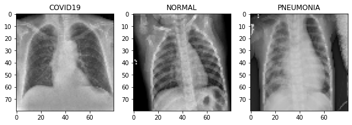

```python
plot(b)
```

#### نمایش نمونه ای از هر کلاس داده های آزمون

```python
c = testData.next()
```

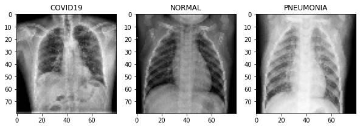

```python
plot(c)
```

## 2.2.Distribution of each class

**2.2) تعداد تصاویر هر دسته را محاسبه کنید و برای آن نمودار میله ای رسم کنید.**

در این قسمت برای راحتی کار چند تابع پیاده سازی شده است:  
1) countEachClass: این تابع درون خود یک دیکشنری که کلید هایش کلاس ها و مقدار هر کلید تعداد آن کلاس است را نگه می دارد و با بررسی تک تک داده ها بررسی می کند مربوط به کدادم کلاسند و بنا به شرایط تعداد کلاس را بروزرسانی می کند.  
2) distributionPlot: در این تابع با کمک bar نمودار میله ای گستردگی هر کدادم از دسته ها درون تمام داده ها را رسم میکنیم

```python
def countEachClass(data):
    res = {}
    labels = {0: 'COVID19', 1: 'NORMAL', 2: 'PNEUMONIA'}
    for i in range(data.n):
        label = data.labels[i]
        strLabel = labels[label]
        if strLabel in res:
            res[strLabel] += 1
        else:
            res[strLabel] = 1
    return res
```

```python
def distributionPlot(inDict):
    plt.bar(range(len(inDict)), list(inDict.values()))
    plt.xticks(range(len(inDict)), list(inDict.keys()))
    plt.show()
```

#### نمایش گستردگی هر کلاس داده های آموزش

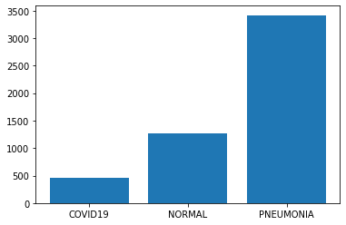

```python
train = countEachClass(trainData)
distributionPlot(train)
```

#### نمایش گستردگی هر کلاس داده های آزمون

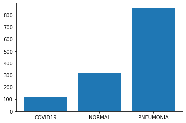

```python
test = countEachClass(testData)
distributionPlot(test)
```

# Neural Network Implementation

## Needed Functions

در این قسمت طبق خواسته پروژه و مواردی که بایستی برای شبکه در نظر بگیریم، توابع زیر را پیاده سازی کردیم.  
1) addInputLayer: این تابع همانطور که از اسمش مشخص است لایه ورودی شبکه را پیاده سازی می کند. تنها یک لایه با شکل تصویر ورودی که 80 در 80 در 1 است. این لایه با کمک layers.Input پیاده سازی می شود.  
2) addHiddenLayer: این تابع همانطور که از اسمش مشخص است لایه های مخفی و میانی شبکه را پیاده سازی می کند. برای پیاده سازی این لایه به تعداد نورون هایش و نوغ تابع فعال ساز و خروجی لایه قبل نیاز داریم. این لایه با کمک layers.Dense پیاده سازی می شود.  
3) addOutputLayer: این تابع همانطور که از اسمش مشخص است لایه های پایانی و خروجی شبکه را پیاده سازی می کند. برای پیاده سازی این لایه به تعداد کلاس های ممکن برای داده ها و نوغ تابع فعال ساز که همیشه softmax است و خروجی لایه قبل نیاز داریم. این لایه با کمک layers.Dense پیاده سازی می شود.  
4) createNetwork: این تابع با کمک کلاس Model شبکه ای با لایه ورودی و لایه خروجی تعریف شده تولید می کند. سپس با بهینه ساز داده شده و تابع loss تعیین شده و معیاری که می خواهیم مدل بر اساسش ارزیابی شود، مدل را کامپایل می کند.  
5) plotHistoryInfo: این تابع با کمک history تولید شده از مدل نمودار های دقت و loss بر حسب شماره epoch به ازای دسته آزمون و آموزش را رسم می کند.  
6) getLabelBatchByBatch: در batch ها ترتیب داده ها همانند ورودی دادهد شده نیست بنابراین با این تابع برای ترتیب جدید داده ها کلاس هر داده را پیدا می کنیم. بدین گونه که در یک حلقه به طول تعداد batch ها کل batch را پیمایش می کنیم و با کمک next و عضو دوم برگردانده شده کلاس را می یابیم. و لیست کلاس ها را بر می گردانیم.  
7) getReport: این تابع با کمک لیست حاصل از داده بالا که کلاس های حقیقی اند و لیست حاصل از پیش بینی مدل از داده ها گزارشی از معیار های گوناگون را با کمک تابع classification_report کتابخانه sklearn تولید می کند.  
از این توابع در قسمت های بعد استفاده خواهیم کرد.

```python
def addInputLayer():
    input = layers.Input(shape=(80, 80, 1))
    return input
```

```python
def addHiddenLayer(preLayer, units, actFunc):
    layer = layers.Dense(units, activation=actFunc)(preLayer)
    return layer
```

```python
def addOutputLayer(preLayer, labelCnt, actFunc):
    outLayer = layers.Dense(labelCnt, activation=actFunc)(preLayer)
    return outLayer
```

```python
def createNetwork(inputLayer, outputLayer, opt, lossFunc):
    model = models.Model(inputs = inputLayer, outputs = outputLayer)
    model.compile(optimizer = opt, loss = lossFunc, metrics=['accuracy'])
    return model
```

```python
def plotHistoryInfo(history, epochNum):
    toPlotTrainAcc = history["accuracy"]
    toPlotTestAcc = history["val_accuracy"]
    toPlotTrainLoss = history["loss"]
    toPlotTestLoss = history["val_loss"]
    epochNum = list(range(1,len(toPlotTestAcc)+1))
    plt.figure(figsize=(15,5))
    plt.subplot(1, 2, 1)
    plt.plot(epochNum, toPlotTrainAcc)
    plt.plot(epochNum, toPlotTestAcc)
    plt.legend(["train","test"])
    plt.title("Accuracy",fontweight = "bold")
    plt.xlabel("Epoch count")
    plt.ylabel("Accuracy")
    plt.subplot(1, 2, 2)
    plt.plot(epochNum, toPlotTrainLoss)
    plt.plot(epochNum,toPlotTestLoss)
    plt.legend(["train","test"])
    plt.title("Loss",fontweight = "bold")
    plt.xlabel("Epoch count")
    plt.ylabel("Loss")
    plt.show()
```

```python
def getLabelBatchByBatch(data):
    labels = []
    batchCnt = data.n//data.batch_size if (data.n//data.batch_size == data.n/data.batch_size) else (data.n//data.batch_size) + 1
    # print(data.n, data.batch_size, batchCnt)
    for i in range(batchCnt):
        newData = data.next()
        for y in newData[1]:
      # labels.append(getLabel(y))
      # labels.append(backend.argmax(y))
            labels.append(getLabel(y))
    # print(np.array(labels))
    return np.array(labels)
```

```python
def getReport(trainedModel, data):
    y_true = getLabelBatchByBatch(data)
    predicted = trainedModel.predict(data)
    y_pred = []
    for onehot in predicted:
        y_pred.append(getLabel(onehot))
  # y_pred = np.argmax(predicted,axis=1)
  # print("B:",y_pred)
    print(classification_report(y_true, y_pred))
```

# Question 3

در این قسمت ابتدا با توجه به شرایط بیان شده در صورت پروژه و توابع تعریف شده در بالا شبکه مورد نظر را پیاده سازی می کنیم.

```python
input = addInputLayer()
inLayer = layers.Flatten()(input)
hiddenLayer1 = addHiddenLayer(inLayer, 1024, "relu")
hiddenLayer2 = addHiddenLayer(hiddenLayer1, 1024, "relu")
outLayer = addOutputLayer(hiddenLayer2, 3, "softmax")
```

```python
opt = optimizers.SGD(learning_rate=0.01)
reluModel = createNetwork(input, outLayer, opt, "categorical_crossentropy")
```

**3) تعداد پارامتر های هر لایه را چاپ کرده.**

با کمک فراخوانی دستور summary() بر روی مدل می توان خلاصه ای از ساختار مدل از جمله پارامتر های هر لایه را ببینیم.

```python
reluModel.summary()
```

```
Model: "model"
_________________________________________________________________
Layer (type)                 Output Shape              Param #
=================================================================
input_1 (InputLayer)         [(None, 80, 80, 1)]       0
_________________________________________________________________
flatten (Flatten)            (None, 6400)              0
_________________________________________________________________
dense (Dense)                (None, 1024)              6554624
_________________________________________________________________
dense_1 (Dense)              (None, 1024)              1049600
_________________________________________________________________
dense_2 (Dense)              (None, 3)                 3075
=================================================================
Total params: 7,607,299
Trainable params: 7,607,299
Non-trainable params: 0
_________________________________________________________________
```

**اعداد چاپ شده را توجیه کنید.**

همانطور که دیده می شود در هر لایه شبکه تعدادی پارامتر جهت آموزش دیدن وجود دارند. این پارامترها عملاً همان وزنهای لایه و بایاس هستند که بایستی آموزش ببینند و به مقدار بهینه خود و مقداری که گرادیان خطا را کمینه کند نزدیک شوند. حال به توجیه تعداد پارامتر های هر لایه می پردازیم.  
1) لایه ورودی: این لایه هیچ پارامتری جهت آموزش ندارد و تنها ورودی را می گیرد و وارد شبکه می کند.  
2) لایه flatten: این لایه هم پارامتری جهت آموزش ندارد. تنها شکل داده ورودی را که چند بعدی است؛ مسطح می کند. بنابراین سایز آن معادل حاصل ضرب ابعاد ورودی است که اینجا می شود 80*80 و همان 6400 است.  
3) لایه dense: در این لایه ها هر ورودی با یک بردار وزن به یک خروجی متصل شده بنابراین به اندازه حاصل ضرب تعداد ورودی ها و تعداد خروجی ها بردار وزن جهت آموزش داریم. همچنین برای هر خروجی یک بردار بایاس داریم که بایستی آموزش ببیند بنابراین به تعداد خروجی بردار بایاس جهت آموزش داریم. در کل به تعداد حاصل ضرب تعداد خروجی ها در یکی بیشتر از ورودی ها پارامتر جهت آموزش داریم. مثلاً اینجا:  
برای لایه dense داریم: (6400+1)* 1024  
برای لایه dense_1 داریم: (1024+1)* 1024  
برای لایه dense_2 داریم: (1024+1)* 3  
تعداد کل پارامتر ها هم از حاصل جمع کل پارامتر ها به دست می آید.

# Question 4

## 4.1.Relu Model - Raw Data

```python
reluRaw = reluModel.fit(trainData, validation_data=testData, epochs=10)
```

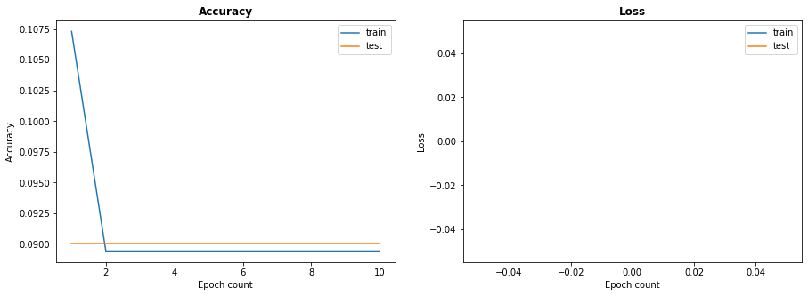

```python
plotHistoryInfo(reluRaw.history, 10)
```

```python
getReport(reluModel, trainData)
```

```
              precision    recall  f1-score   support

           0       0.09      1.00      0.17       466
           1       0.00      0.00      0.00      1274
           2       0.00      0.00      0.00      3404

    accuracy                           0.09      5144
   macro avg       0.03      0.33      0.06      5144
weighted avg       0.01      0.09      0.02      5144
```

```python
getReport(reluModel, testData)
```

```
              precision    recall  f1-score   support

           0       0.09      1.00      0.17       117
           1       0.00      0.00      0.00       318
           2       0.00      0.00      0.00       853

    accuracy                           0.09      1288
   macro avg       0.03      0.33      0.06      1288
weighted avg       0.01      0.09      0.02      1288
```

**4.1) نتیجه حاصل از تمرین همراه با تابع فعال ساز relu را توجیه کنید.**

همانطور که دیده می شود مفدار loss با این تابع فعال ساز nan شده است از دو جنبه می توان این نتیجه را توجیه کرد:  
1)Relu یک مشکل دارد که اصطلاحاً به آن dying RELU می گویند. همانطور که می دانیم در اعداد منفی مقدار و مشتق Relu صفر است یعنی گرادیان هم به سمت صفر می رود. وزن ها هنگام بروزرسانی با شرایط منطبق نمی شوند و بروزرسانی نمی شوند. عملاً نورون دیگر به خطا و ورودی های مختلف ری اکشن نشان نمی دهد و چون گرادیان صفر است چیزی تغییر نمی کند. بنابراین به معنای واقعی تعدادی از نورون ها را از دست می دهیم و سرعت بهبودی و میزان آن بسیار کم می شود. بنابراین خطا بسیار بالا می رود.  
2)اگر تابع loss را بررسی کنیم می بینیم در پیاده سازی آن از تابع softmax بر روی خروجی لایه آخر استفاده شده است. تابع softmax در فرمولش قسمتی به شکل تابع نمایی خروجی لایه آخر دارد. می دانیم تابع Relu اگر عدد مثبت باشد خود عدد را برمی گرداند. بنابراین اگر عدد بسیار بزرگ هم باشد همان را برمیگرداند که حاصل تابع نمایی اش بسیار بالا و باعث overflow می شود و به nan می انجامد.

## 4.1.Tanh Model - Raw Data

```python
input = addInputLayer()
inLayer = layers.Flatten()(input)
hiddenLayer1 = addHiddenLayer(inLayer, 1024, "tanh")
hiddenLayer2 = addHiddenLayer(hiddenLayer1, 1024, "tanh")
outLayer = addOutputLayer(hiddenLayer2, 3, "softmax")
```

```python
opt = optimizers.SGD(learning_rate=0.01)
tanhModel = createNetwork(input, outLayer, opt, "categorical_crossentropy")
```

```python
tanhRaw = tanhModel.fit(trainData, validation_data=testData, epochs=10)
```

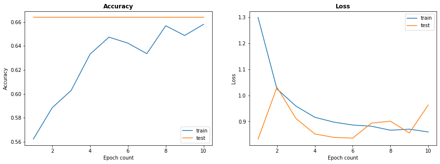

```python
plotHistoryInfo(tanhRaw.history, 10)
```

```python
getReport(tanhModel, trainData)
```

```
              precision    recall  f1-score   support

           0       0.00      0.00      0.00       465
           1       0.00      0.00      0.00      1254
           2       0.67      1.00      0.80      3425

    accuracy                           0.67      5144
   macro avg       0.22      0.33      0.27      5144
weighted avg       0.44      0.67      0.53      5144
```

```python
getReport(tanhModel, testData)
```

```
              precision    recall  f1-score   support

           0       0.00      0.00      0.00       116
           1       0.00      0.00      0.00       319
           2       0.66      1.00      0.80       853

    accuracy                           0.66      1288
   macro avg       0.22      0.33      0.27      1288
weighted avg       0.44      0.66      0.53      1288
```

**4.2) نتیجه حاصل از تمرین همراه با تابع فعال ساز tanh را توجیه کنید.**

همانطور که دیده می شود مفدار loss با این تابع فعال ساز nan نشده است اما شبکه با دقت کم و خطای زیادی عمل می کند.  
همانطور که در تصویر پایین میبینم تابع tanh حد مرزی دارد و زمانی که به سمت بینهایت می رود تغییراتش بسیار کم می شود. در کل، مقادیر بزرگ به سمت یک و مقادیر کوچک به سمت -1 در tanh می روند.(saturation) در نتیجه در این دو ناحیه حساسیت زیادی ندارند و مقدار گرادیان و وزن ها تغییر زیادی نمی کند که بتواند آموزش را بهبود ببخشد. عملاً مشتق در دو ناحیه کنازی بسیار کم است و تنها در نقاط میانی ورودی ها حساس هستند. و در اینجا داده ها گسترده اند یعنی از ناحیه های کناری هم هستند که سرعت آموزش را به خاطر کم بود مشتق کاهش می دهند.

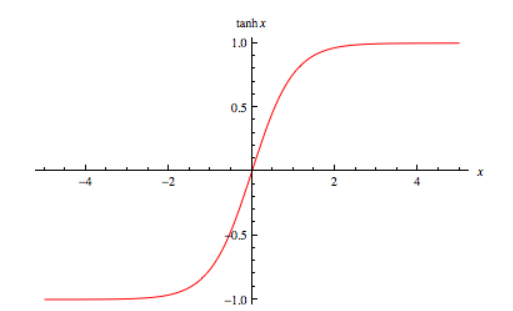

**4.3) علت مشاهدات متفاوت درباره دوتابع استفاده شده و نکته مشترک تمرین هر دو مدل چیست؟**

تفاوت این دو تابع در این است که relu با خروجی دادن عیناً عدد و تولید ورودی بزرگ برای تابع نمایی به تولید loss بسیار بزرگ و ایجاد nan می انجامد. اما tanh با خروجی داده مطابق تصویر بالا و در یک محدوده خاص جلوی overflow شدن را میگیرد.  
شباهت این دو در کاهش سرعت یادگیری و توقف بروز شدن گرادیان در بعضی حالات است. برای relu در اعداد منفی و برای tanh در دو ناحیه مرزی.

**راهکار شما برای حل این مشکل چیست؟**

می توان مشکل dying Relu را با کمک تابع فعال ساز leaky relu تا حد خوبی برطرف کرد. اما مشکل دیگر که اشتراک دو تابع فعال ساز بود را با کمک نرمال کردن داده ها حل می کنیم. برای relu نرمال سازی کمک می کند داده ها در محدوده کوچکتر و در کل اعداد کوچکتر وارد relu و درنتیجه از آن خارج شوند.  
برای tanh نرمال کردن داده ها کمک می کند داده ها در ناحیه های مرکزی که حساسیت بیشتری دارند با احتمال بیشتری قرار بگیرند.

# Question 5

## Normalize Data

در این قسمت همانطور که در قسمت خواندن داده ها توضیح داده شد با کمک True قرار دادن ورودی normalize هر پیکسل بر 255 تقسیم می شود. بنابراین از بعد این قسمت با داده های نرمال شده کار خواهیم کرد.

```python
normalizedTrainData = analyzeData("/content/Data/train", normalize=True)
```

```
Found 5144 images belonging to 3 classes.
Size of data is: 5144 - Number of classes is : 3 - Classes are : {'COVID19': 0, 'NORMAL': 1, 'PNEUMONIA': 2}
```

```python
normalizedTestData = analyzeData("/content/Data/test", normalize=True)
```

```
Found 1288 images belonging to 3 classes.
Size of data is: 1288 - Number of classes is : 3 - Classes are : {'COVID19': 0, 'NORMAL': 1, 'PNEUMONIA': 2}
```

در اینجا در قدم اوّل تاثیر نرمال سازی بر دو تابع فعال ساز مرحله قبل بررسی شد که همانطور که در نمودار ها و گزارش مربوط به معیارهای ارزیابی هر یک میبینیم، نتایج بسیار بهتر و دقت ها بسیار بالاتر شده اند.

## Relu Model - Normalized Data

```python
input = addInputLayer()
inLayer = layers.Flatten()(input)
hiddenLayer1 = addHiddenLayer(inLayer, 1024, "relu")
hiddenLayer2 = addHiddenLayer(hiddenLayer1, 1024, "relu")
outLayer = addOutputLayer(hiddenLayer2, 3, "softmax")
```

```python
opt = optimizers.SGD(learning_rate=0.01)
normReluModel = createNetwork(input, outLayer, opt, "categorical_crossentropy")
```

```python
normRelu = normReluModel.fit(normalizedTrainData, validation_data=normalizedTestData, epochs=10)
```

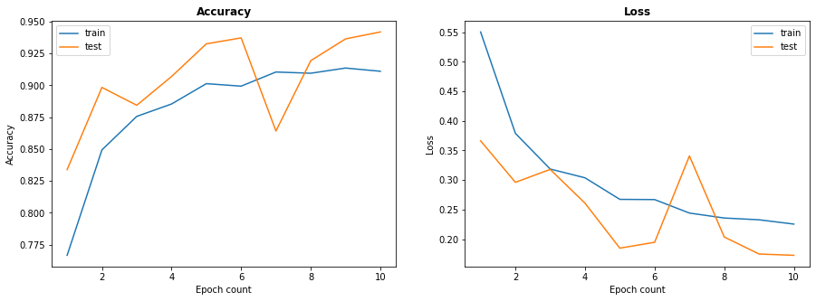

```python
plotHistoryInfo(normRelu.history, 10)
```

```python
getReport(normReluModel, normalizedTrainData)
```

```
              precision    recall  f1-score   support

           0       0.97      0.83      0.90       460
           1       0.86      0.91      0.88      1266
           2       0.95      0.95      0.95      3418

    accuracy                           0.93      5144
   macro avg       0.93      0.90      0.91      5144
weighted avg       0.93      0.93      0.93      5144
```

```python
getReport(normReluModel, normalizedTestData)
```

```
              precision    recall  f1-score   support

           0       0.99      0.82      0.90       116
           1       0.88      0.93      0.91       317
           2       0.96      0.96      0.96       855

    accuracy                           0.94      1288
   macro avg       0.94      0.90      0.92      1288
weighted avg       0.94      0.94      0.94      1288
```

## Tanh Model - Normalized Data

```python
input = addInputLayer()
inLayer = layers.Flatten()(input)
hiddenLayer1 = addHiddenLayer(inLayer, 1024, "tanh")
hiddenLayer2 = addHiddenLayer(hiddenLayer1, 1024, "tanh")
outLayer = addOutputLayer(hiddenLayer2, 3, "softmax")
```

```python
opt = optimizers.SGD(learning_rate=0.01)
normalizedTanhModel = createNetwork(input, outLayer, opt, "categorical_crossentropy")
```

```python
hist = normalizedTanhModel.fit(normalizedTrainData, validation_data=normalizedTestData, epochs=10)
```

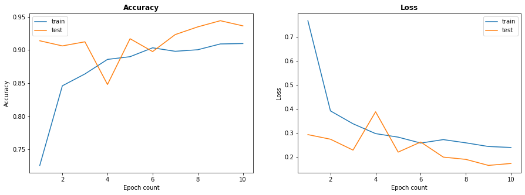

```python
plotHistoryInfo(hist.history, 10)
```

```python
getReport(normalizedTanhModel, normalizedTrainData)
```

```
              precision    recall  f1-score   support

           0       0.89      0.90      0.90       460
           1       0.85      0.90      0.87      1266
           2       0.96      0.94      0.95      3418

    accuracy                           0.92      5144
   macro avg       0.90      0.91      0.90      5144
weighted avg       0.92      0.92      0.92      5144
```

```python
getReport(normalizedTanhModel, normalizedTestData)
```

```
              precision    recall  f1-score   support

           0       0.90      0.94      0.92       116
           1       0.87      0.92      0.90       317
           2       0.97      0.94      0.95       855

    accuracy                           0.94      1288
   macro avg       0.91      0.93      0.92      1288
weighted avg       0.94      0.94      0.94      1288
```

## Better F1-score Model

حال از ما خواسته شده است شبکه ای را بیابیم که بیشترین مقدار F1 برای نتیجه روی داده تست ایجاد شود. برای مقدار بیشترین نمی توان دقیق حد تعیین کرد بنابراین من در اینجا سعی کردم شبکه ای طراحی کنم که از دو حالت بالا که نتایج خوبی داشتند، F1 بالاتری برای داده تست تولید کند. برای ساخت این مدل از تابع فعال ساز relu استفاده شده است که نتایج خوبی داشت. سپس با افزودن دو لایه مخفی دیگر پیچیدگی شبکه را بیشتر کردم تا سطح آموزش بالاتر رود. تعداد نورون ها با آزمون و خطا و جابجایی لایه ها به دست آمد. برای مثال ابتدا لایه اول 4096 نورون داشت اما با جابجایی آن و تست دوباره نتیجه بهتری حاصل شد. همچنین در مدل اولیه هر لایه 1024 نورون داشت که در اینجا با ضرایب آن کار کردم.

```python
input = addInputLayer()
inLayer = layers.Flatten()(input)
hiddenLayer1 = addHiddenLayer(inLayer, 2048, "relu")
hiddenLayer2 = addHiddenLayer(hiddenLayer1, 4096, "relu")
hiddenLayer3 = addHiddenLayer(hiddenLayer2, 2024, "relu")
hiddenLayer4 = addHiddenLayer(hiddenLayer3, 2048, "relu")
outLayer = addOutputLayer(hiddenLayer4, 3, "softmax")
```

```python
opt = optimizers.SGD(learning_rate=0.01)
bestModel = createNetwork(input, outLayer, opt, "categorical_crossentropy")
```

```python
best = bestModel.fit(normalizedTrainData, validation_data=normalizedTestData, epochs=10)
```

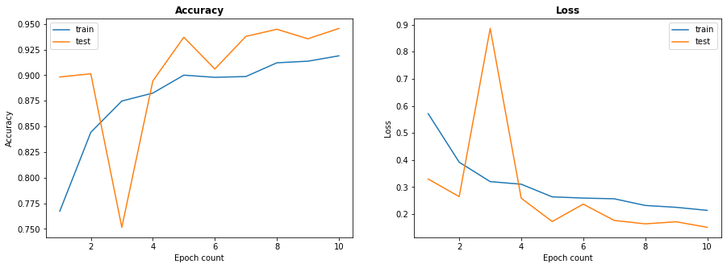

```python
plotHistoryInfo(best.history, 10)
```

```python
getReport(bestModel, normalizedTrainData)
```

```
              precision    recall  f1-score   support

           0       0.92      0.92      0.92       460
           1       0.90      0.88      0.89      1266
           2       0.95      0.96      0.96      3418

    accuracy                           0.94      5144
   macro avg       0.92      0.92      0.92      5144
weighted avg       0.94      0.94      0.94      5144
```

```python
getReport(bestModel, normalizedTestData)
```

```
              precision    recall  f1-score   support

           0       0.93      0.93      0.93       116
           1       0.91      0.91      0.91       317
           2       0.96      0.96      0.96       855

    accuracy                           0.95      1288
   macro avg       0.93      0.93      0.93      1288
weighted avg       0.95      0.95      0.95      1288
```

همانطور که در نتایج بالا میبینیم f1 داده های تست از دو حالت قبلی هم بهتر هستند و بالای 90 در صد هستند که بسیار مناسب و خوب است.

# Question 6

**6.1) momentum چیست و چرا استفاده از آن مفید است؟**

momentum در اصل یک خاصیت فیزیکی است که باعث می شود یک جسم وزن دار در مسیرش به حرکت ادامه دهد حتی با وجود یک نیروی خارجی وارده در جهت مخالف. مانند ماشینی که با سرعت بالا در حال حرکت است و ناگهان ترمز می کند. این ماشین مسافتی را تا قبل از ایست کامل می پیماید.  
با کمک روش gradient descent ما مشتق دقیق مربوط به تابع خطا را حساب نمی کنیم، بلکه تنها برای قسمت کوچکی از داده ها این محاسبه را انجام می دهیم. در نتیجه این محاسبات همیشه دقیق نیست و در جهت کمینه کردن پیش نمی رود. زیرا این مشتق ها در دسته های کوچک داده همراه با نویز هستند. بنابراین به روشی نیاز داریم تا سایز قدم هایی که به سمت مقدار کمینه خطا برمی داریم را افزایش دهد. momentum این کار را برای ما انجام می دهد. با کمک momentum تنها خطای مرحله های فعلی در نظر گرفته نمی شود بلکه وزن بروزشده مرحله قبل هم تاثیر داده می شود. عملاً momentum یک حافظه کوتاه مدت به بهینه ساز می دهد به جای آنکه تنها به گرادیان این مرحله اتکا کند.

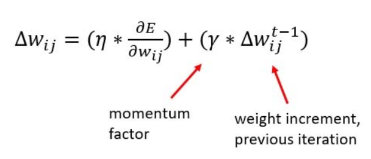

فایده momentum در این است که با افزایش سایز قدم ها در اصل مانع ایستادن گرادیان در یک مقدار کمینه محلی می شود و آن را مجبور می کند در جهت مسیر کاهنده اش ادامه دهد به امید آن که در یک کمینه واقعی قرار بگیرد. در اصل momenum با هل دادن گرادیان به سمت کمینه واقعی سرعت یادگیری را افزایش می دهد. اما باید مراقب این افزایش سرعت و مقدار آن مخصوصاً در کنار learning rate باشیم. مفهوم این توجه در مرحله بعد بهتر مشخص می شود.

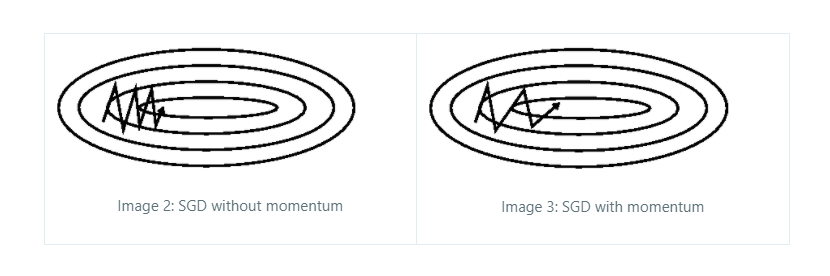

## 6.2.Different momentum

### Momentum = 0.5

```python
input = addInputLayer()
inLayer = layers.Flatten()(input)
hiddenLayer1 = addHiddenLayer(inLayer, 2048, "relu")
hiddenLayer2 = addHiddenLayer(hiddenLayer1, 4096, "relu")
hiddenLayer3 = addHiddenLayer(hiddenLayer2, 2024, "relu")
hiddenLayer4 = addHiddenLayer(hiddenLayer3, 2048, "relu")
outLayer = addOutputLayer(hiddenLayer4, 3, "softmax")
```

```python
opt = optimizers.SGD(learning_rate=0.01, momentum=0.5)
firstMomentumModel = createNetwork(input, outLayer, opt, "categorical_crossentropy")
```

```python
firstMomentum = firstMomentumModel.fit(normalizedTrainData, validation_data=normalizedTestData, epochs=10)
```

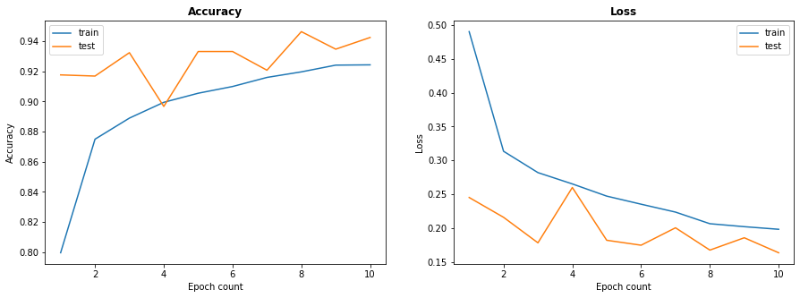

```python
plotHistoryInfo(firstMomentum.history, 10)
```

```python
getReport(firstMomentumModel, normalizedTrainData)
```

```
              precision    recall  f1-score   support

           0       0.97      0.89      0.93       460
           1       0.86      0.93      0.90      1266
           2       0.97      0.95      0.96      3418

    accuracy                           0.94      5144
   macro avg       0.93      0.92      0.93      5144
weighted avg       0.94      0.94      0.94      5144
```

```python
getReport(firstMomentumModel, normalizedTestData)
```

```
              precision    recall  f1-score   support

           0       0.98      0.86      0.92       116
           1       0.87      0.94      0.90       317
           2       0.97      0.95      0.96       855

    accuracy                           0.94      1288
   macro avg       0.94      0.92      0.93      1288
weighted avg       0.94      0.94      0.94      1288
```

در حالی که momentum برابر با 0.5 باشد نتایج از نظر دقت و معیار ها رشد چشم گیری ندارند امّا اگر در نمودار دقیق شویم متوجه می شویم داده تست در دقت آن سقوط شدید مرحله قبل را نداشت. این نشان می دهد تا حدی جلوی نویز های گرادیان ها گرفته شده است.

### Momentum = 0.9

```python
input = addInputLayer()
inLayer = layers.Flatten()(input)
hiddenLayer1 = addHiddenLayer(inLayer, 2048, "relu")
hiddenLayer2 = addHiddenLayer(hiddenLayer1, 4096, "relu")
hiddenLayer3 = addHiddenLayer(hiddenLayer2, 2024, "relu")
hiddenLayer4 = addHiddenLayer(hiddenLayer3, 2048, "relu")
outLayer = addOutputLayer(hiddenLayer4, 3, "softmax")
```

```python
opt = optimizers.SGD(learning_rate=0.01, momentum=0.9)
secondMomentumModel = createNetwork(input, outLayer, opt, "categorical_crossentropy")
```

```python
secondMomentum = secondMomentumModel.fit(normalizedTrainData, validation_data=normalizedTestData, epochs=10)
```

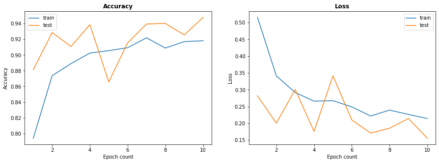

```python
plotHistoryInfo(secondMomentum.history, 10)
```

```python
getReport(secondMomentumModel, normalizedTrainData)
```

```
              precision    recall  f1-score   support

           0       0.93      0.90      0.91       460
           1       0.89      0.90      0.89      1266
           2       0.96      0.96      0.96      3418

    accuracy                           0.94      5144
   macro avg       0.92      0.92      0.92      5144
weighted avg       0.94      0.94      0.94      5144
```

```python
getReport(secondMomentumModel, normalizedTestData)
```

```
              precision    recall  f1-score   support

           0       0.94      0.91      0.93       116
           1       0.90      0.94      0.92       317
           2       0.97      0.96      0.96       855

    accuracy                           0.95      1288
   macro avg       0.94      0.94      0.94      1288
weighted avg       0.95      0.95      0.95      1288
```

در حالی که momentum برابر با 0.9 باشد نتایج از نظر دقت و معیار ها در داده های تست مقدار کمی رشد داشته است. این بدین معنی است که این شبکه با وجودی که فکر می کردیم معماری مناسبی دارد، در بعضی از نقاط گرادیان دچار کمینه محلی می شده است که بدون میزان صحیح افزایش سایز قدم دیرتر به جواب بهینه اش میرسیده است و اینجا این فرآیند سریعتر شده است.

### Momentum = 0.99

```python
input = addInputLayer()
inLayer = layers.Flatten()(input)
hiddenLayer1 = addHiddenLayer(inLayer, 2048, "relu")
hiddenLayer2 = addHiddenLayer(hiddenLayer1, 4096, "relu")
hiddenLayer3 = addHiddenLayer(hiddenLayer2, 2024, "relu")
hiddenLayer4 = addHiddenLayer(hiddenLayer3, 2048, "relu")
outLayer = addOutputLayer(hiddenLayer4, 3, "softmax")
```

```python
opt = optimizers.SGD(learning_rate=0.01, momentum=0.99)
thirdMomentumModel = createNetwork(input, outLayer, opt, "categorical_crossentropy")
```

```python
thirdMomentum = thirdMomentumModel.fit(normalizedTrainData, validation_data=normalizedTestData, epochs=10)
```

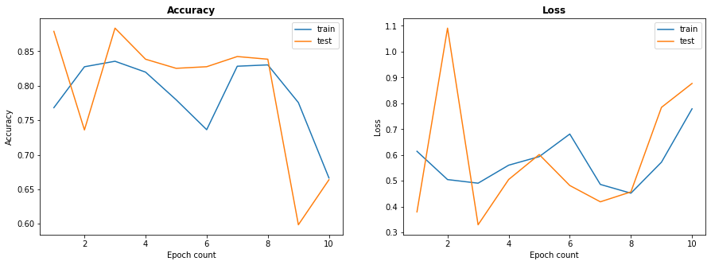

```python
plotHistoryInfo(thirdMomentum.history, 10)
```

```python
getReport(thirdMomentumModel, normalizedTrainData)
```

```
              precision    recall  f1-score   support

           0       0.00      0.00      0.00       460
           1       0.00      0.00      0.00      1266
           2       0.66      1.00      0.80      3418

    accuracy                           0.66      5144
   macro avg       0.22      0.33      0.27      5144
weighted avg       0.44      0.66      0.53      5144
```

```python
getReport(thirdMomentumModel, normalizedTestData)
```

```
              precision    recall  f1-score   support

           0       0.00      0.00      0.00       116
           1       0.00      0.00      0.00       317
           2       0.66      1.00      0.80       855

    accuracy                           0.66      1288
   macro avg       0.22      0.33      0.27      1288
weighted avg       0.44      0.66      0.53      1288
```

در حالی که momentum برابر با 0.99 باشد نتایج از نظر دقت و معیار ها بسیار خراب شده اند. این نشان می دهد این مقدار برای momentum مقدار بسیار بزرگی است. تاثیر بد بزرگ بودن momentum در قسمت بعد توضیح داده می شود.

**6.3) آیا همواره استفاده از momentum بسیار زیاد مفید است؟**

خیر، همانطور که در مثال بالا میبینیم مقدار بالای momentum می تواند نتیجه را بسیار خراب کند. دلیل این موضوع آن است که همانطور که گفته شد momentum باعث می شود گرادیان در جهت کاسته شدن قدم های بیشتری بردارد و سرعت یادگیری بالا رود. حال اگر این عدد را بسیار بزرگ دهیم ممکن است چنان باعث تغییر گرادیان شود که کمینه واقعی را رد کند. همچنین اگر با یک learning rate بالا همراه شود می تواند چنان سرعت یادگیری را زیاد کند که مقادیر گرادیان ها به شدت تغییر کنند و به کل از جهت کاسته شدن خارج شود مانند نمودار loss مورد بالا که میبینیم loss صعود های شدیدی داشته است.

## 6.4.Using Adam

```python
input = addInputLayer()
inLayer = layers.Flatten()(input)
hiddenLayer1 = addHiddenLayer(inLayer, 2048, "relu")
hiddenLayer2 = addHiddenLayer(hiddenLayer1, 4096, "relu")
hiddenLayer3 = addHiddenLayer(hiddenLayer2, 2024, "relu")
hiddenLayer4 = addHiddenLayer(hiddenLayer3, 2048, "relu")
outLayer = addOutputLayer(hiddenLayer4, 3, "softmax")
```

```python
adamOpt = optimizers.Adam(learning_rate=0.001)
adamModel = createNetwork(input, outLayer, adamOpt, "categorical_crossentropy")
```

```python
adam = adamModel.fit(normalizedTrainData, validation_data=normalizedTestData, epochs=10)
```

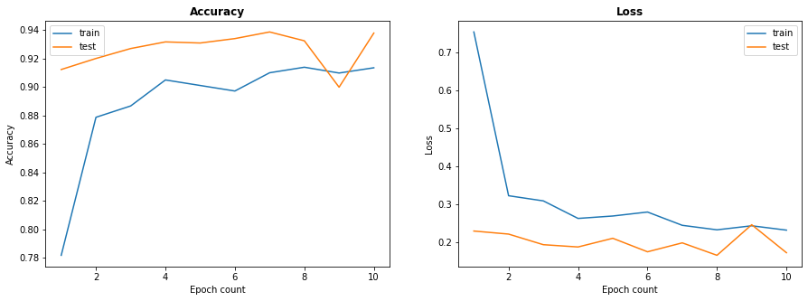

```python
plotHistoryInfo(adam.history, 10)
```

```python
getReport(adamModel, normalizedTrainData)
```

```
              precision    recall  f1-score   support

           0       0.96      0.84      0.90       460
           1       0.94      0.80      0.86      1266
           2       0.92      0.98      0.95      3418

    accuracy                           0.93      5144
   macro avg       0.94      0.87      0.90      5144
weighted avg       0.93      0.93      0.92      5144
```

```python
getReport(adamModel, normalizedTestData)
```

```
              precision    recall  f1-score   support

           0       0.99      0.85      0.92       116
           1       0.94      0.84      0.89       317
           2       0.93      0.98      0.96       855

    accuracy                           0.94      1288
   macro avg       0.95      0.89      0.92      1288
weighted avg       0.94      0.94      0.94      1288
```

در کل Adam ترکیبی از momentum و RMSProp است. که تاثیر مثبت momentum را در قسمت بالا دیدیم. در کل Adam به عنوان تابع بهینه ساز سریعتر نسبت به SGD شناخته می شود و در اکثر مواقع حتی با hyperparameter های از پیش تعیین شده هم مناسب جواب می دهد. در شبکه طراحی شده SGD با اختلاف بسیار کمی بهتر جواب می دهد. که می تواند به دلیل طراحی یا تفاوت learning rate ها باشد و اینکه learning Rate مربوط به SGD بزرگتر است.

# Question 7

## 7.1.Train with epoch = 20

```python
input = addInputLayer()
inLayer = layers.Flatten()(input)
hiddenLayer1 = addHiddenLayer(inLayer, 2048, "relu")
hiddenLayer2 = addHiddenLayer(hiddenLayer1, 4096, "relu")
hiddenLayer3 = addHiddenLayer(hiddenLayer2, 2024, "relu")
hiddenLayer4 = addHiddenLayer(hiddenLayer3, 2048, "relu")
outLayer = addOutputLayer(hiddenLayer4, 3, "softmax")
```

```python
adamOpt = optimizers.Adam(learning_rate=0.001)
moreEpochModel = createNetwork(input, outLayer, adamOpt, "categorical_crossentropy")
```

```python
moreEpoch = moreEpochModel.fit(normalizedTrainData, validation_data=normalizedTestData, epochs=20)
```

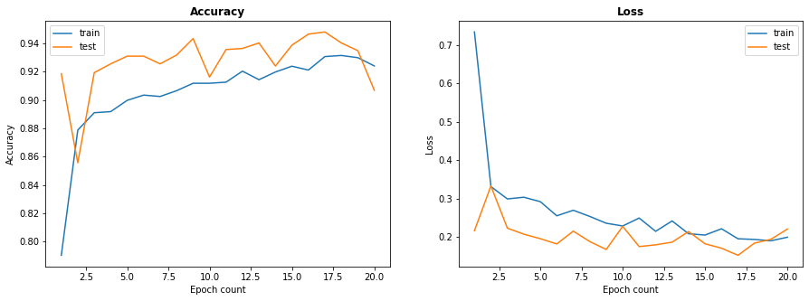

```python
plotHistoryInfo(moreEpoch.history, 20)
```

```python
getReport(moreEpochModel, normalizedTrainData)
```

```
              precision    recall  f1-score   support

           0       0.94      0.84      0.89       460
           1       0.97      0.67      0.79      1266
           2       0.88      0.99      0.93      3418

    accuracy                           0.90      5144
   macro avg       0.93      0.83      0.87      5144
weighted avg       0.91      0.90      0.89      5144
```

```python
getReport(moreEpochModel, normalizedTestData)
```

```
              precision    recall  f1-score   support

           0       0.96      0.86      0.91       116
           1       0.97      0.70      0.81       317
           2       0.89      0.99      0.94       855

    accuracy                           0.91      1288
   macro avg       0.94      0.85      0.89      1288
weighted avg       0.91      0.91      0.90      1288
```

**7.2) چرا معمولاً شبکه های عصبی را در چندین epoch تمرین می دهند؟**  
داده هایی که جهت آموزش داده می شوند داده هایی متناهی هستند اما فرآیند آموزش براساس gradient descent است که یک فرآیند پیوسته و تکراری است و نمی توان مطمئن بود با حجم متناهی داده هایمان به مینیمم گرادیان خواهیم رسید بنابراین چند بار از آن داده ها طی چند Epoch استفاده می کنیم تا وزن ها بتوانند تا زمان رسیدن به مینیمم گرادیان خود را بروز کنند و داده ها تمام نشوند.

**آیا در همه مسائل نیاز به آن است که شبکه عصبی در چندین epoch تمرین نماید؟**  
بله زیرا داده های لیبل زده شده در هیج مسئله ای چنان زیاد نیست که تنها با یکبار استفاده از آن و آموزش دیدن با کمک آن مطمئن باشیم شبکه با دقت خوبی می تواند کلاس را مشخص کند.

**7.2) آیا همواره استفاده از تعداد epochهای بیشتر برای تمرین مفید است؟ اگر جواب شما منفی است، راه حل های مقابله با اتفاق نامطلوبی که روی می دهد را بیان کنید.**  
خیر، از جایی به بعد ممکن است افزایش تعداد epoch ها تنها پیچیدگی شبکه را بالا ببرد یعنی شبکه تا حد خوبی آموزش دیده باشد و با دقت خوبی بتواند کلاس بندی و دیدن epoch های بیشتر تنها باعث ایجاد نویز در شبکه و به اصطلاح overfitting شود.فرآیند overfitting هنگامی رخ می دهد که دقت شبکه روی داده های شبکه شروع به کاهش کند یا هزینه شروع به افزایش کند. یعنی به بیشینه حد دقت برای داده آزمون برسیم و بعد از آن یا دقت ثابت بماند یا کاهش می یابد. در این حالت دقت داده های آموزش همچنان افزایش می یابد و فاصله دقت این دو دسته داده بیشتر و بیشتر می شود. یکی از راه حل های مقابله با این مسئله early stopping است که در پیمایش epoch ها زمانی که دقت آزمون شروع به کاهش کرد یا هزینه آزمون شروع به افزایش کرد امر آموزش و پیمایش epoch ها متوقف شود.

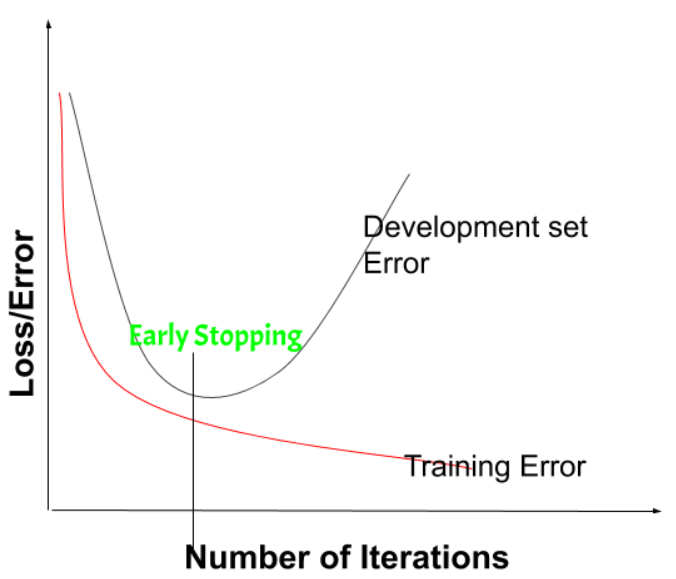

البته با تعدادی دیگر از روش های جلوگیری از overfitting در بخش نه آشنا خواهیم شد.

# Question 8

## 8.1.Use MSE for Loss Function

```python
input = addInputLayer()
inLayer = layers.Flatten()(input)
hiddenLayer1 = addHiddenLayer(inLayer, 2048, "relu")
hiddenLayer2 = addHiddenLayer(hiddenLayer1, 4096, "relu")
hiddenLayer3 = addHiddenLayer(hiddenLayer2, 2024, "relu")
hiddenLayer4 = addHiddenLayer(hiddenLayer3, 2048, "relu")
outLayer = addOutputLayer(hiddenLayer4, 3, "softmax")
```

```python
adamOpt = optimizers.Adam(learning_rate=0.001)
mseLossModel = createNetwork(input, outLayer, adamOpt, "mean_squared_error")
```

```python
mseLoss = mseLossModel.fit(normalizedTrainData, validation_data=normalizedTestData, epochs=20)
```

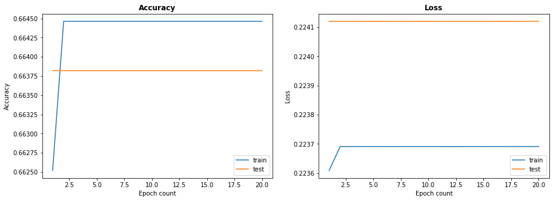

```python
plotHistoryInfo(mseLoss.history, 20)
```

```python
getReport(mseLossModel, normalizedTrainData)
```

```
              precision    recall  f1-score   support

           0       0.00      0.00      0.00       460
           1       0.00      0.00      0.00      1266
           2       0.66      1.00      0.80      3418

    accuracy                           0.66      5144
   macro avg       0.22      0.33      0.27      5144
weighted avg       0.44      0.66      0.53      5144
```

```python
getReport(mseLossModel, normalizedTestData)
```

```
              precision    recall  f1-score   support

           0       0.00      0.00      0.00       116
           1       0.00      0.00      0.00       317
           2       0.66      1.00      0.80       855

    accuracy                           0.66      1288
   macro avg       0.22      0.33      0.27      1288
weighted avg       0.44      0.66      0.53      1288
```

به وضوح نتیجه شبکه عصبی با کمک تابع MSE در مقایسه با categorical cross entropy بسیار ضعیف تر و نامناسب تر بود. همانطور که دیده می شود نمودار دقت و هزینه برای داده های تست تغییری نمی کند و به نظر می آید شبکه آموزشی نمی بیند.

**8.2) چرا استفاده از تابعی مثل MSE برای classification مناسب نیست؟ چه زمانی از این تابع استفاده می کنیم؟**

از چند جنبه می توان توضیح داد چرا MSE تابع مناسبی برای Loss یک دسته بند نیست. تابع MSE میانگین توان دوی اختلاف مقادیر حقیقی و مقادیر پیش بینی شده را حساب می کند. بنابراین مقادیری که با آنها کار می کند می تواند هر مقداری از منفی بی نهایت تا مثبت بی نهایت باشد اما در مسائل دسته بندی ما تنها با احتمال سر و کار داریم. احتمال اینکه بین این کلاس ها این داده به کدام کلاس با احتمال بیشتر تعلق دارد. احتمال ها اعدادی بین صفر و یک است. به همین دلیل است که شبکه ای که با تابع هزینه MSE طراحی می شود هیچ تضمینی ندارد مقدار هزینه را کمینه کند.  
در هنگام استفاده از MSE فرض می کنیم داده ها گستردگی نرمال دارند اما در قسمت اول گستردگی داده ها بررسی شد و به شکل نرمال نمیباشد.  
در کل از این تابع به عنوان تابع هزینه در مسایل تخیمن و regression بهتر است استفاده شود.

# Question 9

## 9.2. L2 regularization

زمانی overfitting رخ می دهد که شبکه پیچیدگی زیادی داشته باشد. اگر مدل را ساده سازی کنیم باعث می شود فقط ویژگی های موردنیاز را آموزش ببیند و به دلیل پیچیدگی مدل سردرگم نشود و تمام نویز ها را هم آموزش نببیند. یکی از راههای ساده سازی کاهش وزن های مدل است. حال چگونه وزن ها را کاهش دهیم؟ با کمک افزایش مقدار Loss. این همان کاری است که L2 regularization انجام می دهد. مقدار افزایش Loss هم از فرمول زیر به دست می آید:
$$loss = l2 * reduce-sum(square(x)) $$ که reduce_sum یکی از توابع tensorflow است.

```python
input = layers.Input(shape=(80, 80, 1))
inLayer = layers.Flatten()(input)
hiddenLayer1 = layers.Dense(2048, activation="relu", kernel_regularizer=regularizers.l2(0.0001))(inLayer)
hiddenLayer2 = layers.Dense(4096, activation="relu", kernel_regularizer=regularizers.l2(0.0001))(hiddenLayer1)
hiddenLayer3 = layers.Dense(2024, activation="relu", kernel_regularizer=regularizers.l2(0.0001))(hiddenLayer2)
hiddenLayer4 = layers.Dense(2048, activation="relu", kernel_regularizer=regularizers.l2(0.0001))(hiddenLayer3)
outLayer = layers.Dense(3, activation="softmax", kernel_regularizer=regularizers.l2(0.0001))(hiddenLayer4)
```

```python
adamOpt = optimizers.Adam(learning_rate=0.001)
regL2Model = models.Model(inputs = input, outputs = outLayer)
regL2Model.compile(optimizer = adamOpt, loss = "categorical_crossentropy", metrics=['accuracy'])
```

```python
regL2 = regL2Model.fit(normalizedTrainData, validation_data=normalizedTestData, epochs=20)
```

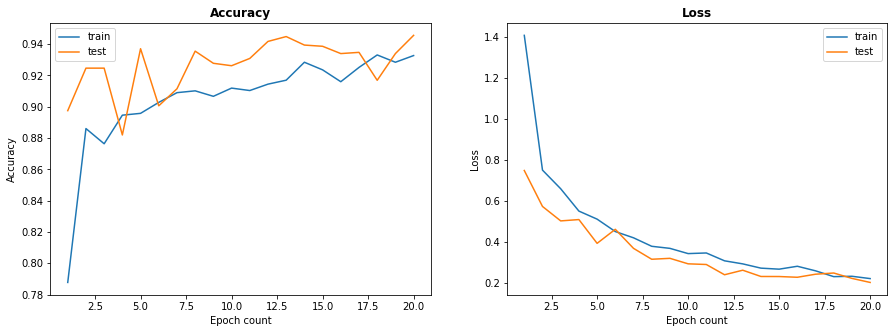

```python
plotHistoryInfo(regL2.history, 20)
```

```python
getReport(regL2Model, normalizedTrainData)
```

```
              precision    recall  f1-score   support

           0       0.09      0.08      0.09       461
           1       0.23      0.23      0.23      1265
           2       0.66      0.67      0.67      3418

    accuracy                           0.51      5144
   macro avg       0.33      0.33      0.33      5144
weighted avg       0.51      0.51      0.51      5144
```

```python
getReport(regL2Model, normalizedTestData)
```

```
              precision    recall  f1-score   support

           0       0.97      0.84      0.90       116
           1       0.91      0.93      0.92       317
           2       0.96      0.97      0.96       855

    accuracy                           0.95      1288
   macro avg       0.95      0.91      0.93      1288
weighted avg       0.95      0.95      0.95      1288
```

همانطور که در نمودار دیده می شود استفاده از regularization L2 باعث شده است دقت داده های آموزش و آزمون و loss داده های آموزش و آزمون همگرا شده اند و overfitting رخ نداده است. مخصوصاً این تاثیر در نمودار Loss قابل مشاهده است.

## 9.3.Dropout

زمانی overfitting رخ می دهد که شبکه روی تعدادی از داده های آموزش متمرکز می شود و آموزش کامل برای ویژگی های آنها و دسته بندی آنها را میبیند بنابراین با دقت خوبی آنها را دسته بندی می کند اما خصوصیت کلی خود را گستردگی اش را از دست می دهد بنابراین داده جدید را با دقت بسیار کمی تشخیص می دهد. بنابراین اگر به گونه ای شبکه را مجبور کنیم با داده ها و ویژگی های مختلف کار کنند دچار overfitting نمی شود. این همان کاری است که در dropout انجام می دهیم. بدین معنا که در هر لایه با فرکانس rate ای که در آرگومان های dropout داده شده است یکی از unit های ورودی را صفر می کند. بنابراین در هر مرحله شبکه مجبور می شود با مجموعه داده ها و ساختار متفاوتی آموزش ببیند.

```python
input = layers.Input(shape=(80, 80, 1))
inLayer = layers.Flatten()(input)
hiddenLayer1 = layers.Dense(2048, activation="relu")(inLayer)
dropLayer1 = layers.Dropout(0.1)(hiddenLayer1)
hiddenLayer2 = layers.Dense(4096, activation="relu", kernel_regularizer=regularizers.l2(0.0001))(dropLayer1)
dropLayer2 = layers.Dropout(0.1)(hiddenLayer2)
hiddenLayer3 = layers.Dense(2024, activation="relu", kernel_regularizer=regularizers.l2(0.0001))(dropLayer2)
dropLayer3 = layers.Dropout(0.1)(hiddenLayer3)
hiddenLayer4 = layers.Dense(2048, activation="relu", kernel_regularizer=regularizers.l2(0.0001))(dropLayer3)
dropLayer4 = layers.Dropout(0.1)(hiddenLayer4)
outLayer = layers.Dense(3, activation="softmax", kernel_regularizer=regularizers.l2(0.0001))(dropLayer4)
```

```python
adamOpt = optimizers.Adam(learning_rate=0.001)
dropoutModel = models.Model(inputs = input, outputs = outLayer)
dropoutModel.compile(optimizer = adamOpt, loss = "categorical_crossentropy", metrics=['accuracy'])
```

```python
dropout = dropoutModel.fit(normalizedTrainData, validation_data=normalizedTestData, epochs=20)
```

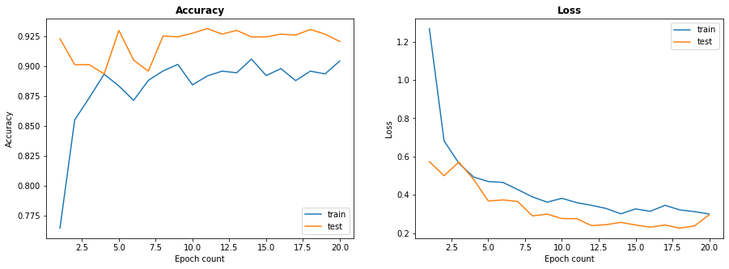

```python
plotHistoryInfo(dropout.history, 20)
```

```python
getReport(dropoutModel, normalizedTrainData)
```

```
              precision    recall  f1-score   support

           0       0.93      0.87      0.90       460
           1       0.85      0.89      0.87      1266
           2       0.95      0.94      0.95      3418

    accuracy                           0.92      5144
   macro avg       0.91      0.90      0.90      5144
weighted avg       0.92      0.92      0.92      5144
```

```python
getReport(dropoutModel, normalizedTestData)
```

```
              precision    recall  f1-score   support

           0       0.91      0.87      0.89       116
           1       0.83      0.91      0.87       317
           2       0.96      0.93      0.95       855

    accuracy                           0.92      1288
   macro avg       0.90      0.90      0.90      1288
weighted avg       0.92      0.92      0.92      1288
```

همانطور که در نمودار دیده می شود استفاده از dropout باعث شده است دقت داده های آموزش و آزمون و loss داده های آموزش و آزمون همگرا شده اند و overfitting رخ نداده است.

## نتیجه گیری

استفاده از کتابخانه ها می تواند کار ما را برای پیاده سازی شبکه های عصبی بسیار ساده کند. امّا باز هم باید به چگونگی معماری و استفاده صحیح از امکانات کتابخانه توجه کنیم. استفاده از کتابخانه کار را راحت می کند اما تضمین کننده معماری مناسب با دقت مناسب و دیگر معیار ها نیست. در هر مسئله ای بنا به شرایط و نوع داده ها و هدف، بایستی معماری مناسب با کمک توابع مختلق کتابخانه را پیاده سازی کنیم.